# Pectobacterium atrosepticum subspecies structure in Scotland

01/11/2017

## 1. Background

## Diagnostics & Classification

- Scottish Government-funded
- RESAS RD2.1.4
- RESAS RD2.1.5
- Sonia Humphris
- Ian Toth
- Emma Campbell

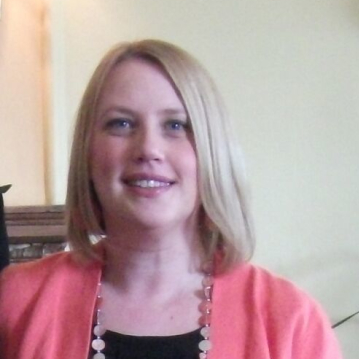

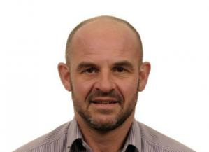

[figure not shown]

## SRE Taxonomy

- enterobacterial taxonomy is difficult to resolve, in general

**Historical classification mostly phenotypic, polyphasic**

- all SRE originally *Erwinia* (1950s - bucket classification)
- now three distinct genera (*Erwinia*, *Dickeya*, *Pectobacterium*)
- binomial nomenclature not designed for large amounts of genome data, or metadata curation
- old names hold over in literature, collections
- name discontinuities affect analyses, databases

- [Czajkowski *et al.* (2015) *Ann. Appl. Biol.* doi:10.1111/aab.12166](https://dx.doi.org/10.1111/aab.12166) - SRE diagnostics

## Historical Taxonomy

- *Erwinia* revised ≈1953 (*Pectobacterium*), ≈2003-2005 (*Dickeya*)

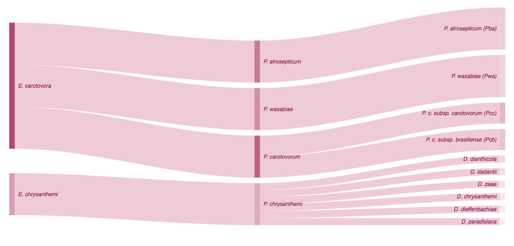

- [Gardan *et al.* (2003) *Int. J. Sys. Microbiol.* doi:10.1099/ijs.0.02423-0](https://dx.doi.org/10.1099/ijs.0.02423-0) - SRE reclassification

- [Samson *et al.* (2005) *Int. J. Sys. Microbiol.* doi:10.1099/ijs.0.02791-0](https://dx.doi.org/10.1099/ijs.0.02791-0) - SRE reclassification

## Taxonomy For Legislation and Policy

**Easy to incorporate into legislation (binary classification)**

- Assumes taxonomy is assigned precisely and correctly
- Assumes taxonomy is a proxy for risk
- Historical phenotypic classification is semi-arbitrary (≈binary tree)
- Is a species concept appropriate for bacteria? (No)
- Is disease risk only transferred parent to offspring? (No: HGT)
- Is there 1:1 mapping from genome/phenotype to disease? (No)
- Are all currently known bacteria correctly classified? (No)

- [Toth et al. (2006) *Ann. Rev. Phyto.* doi:10.1146/annurev.phyto.44.070505.143444](https://dx.doi.org/10.1146/annurev.phyto.44.070505.143444) - horizontal transfer of pathogenicity

- [Deans et al. (2015) *PLoS Biol.* doi:10.1371/journal.pbio.1002033](https://dx.doi.org/10.1371/journal.pbio.1002033) - no 1:1 map from taxonomy to disease

- [Pritchard *et al* (2015) *Anal. Methods* doi:10.1039/c5ay02550h](http://dx.doi.org/10.1039/c5ay02550h): Bacterial pathogen classification for policy

## 2. `pyani`

## `pyani`

- `pyani` evolved from diagnostics work on *Pectobacterium*/*Dickeya*
- computational tool for rapid calculation and analysis of average nucleotide identity (ANI)
  - First release August 2015; Current release: v0.2.7 (Oct 2017)
- Public webpage: http://widdowquinn.github.io/pyani/
- Available as `Docker` container:
  - `docker run -v ${PWD}:/host_dir leightonpritchard/average_nucleotide_identity`

## `pyani`

**`python` package and scripts for ANI**

- available on `PyPI` and `Docker`
- ANIm, ANIb etc.
- calculates, visualises results
- parallelises under SGE/OGE

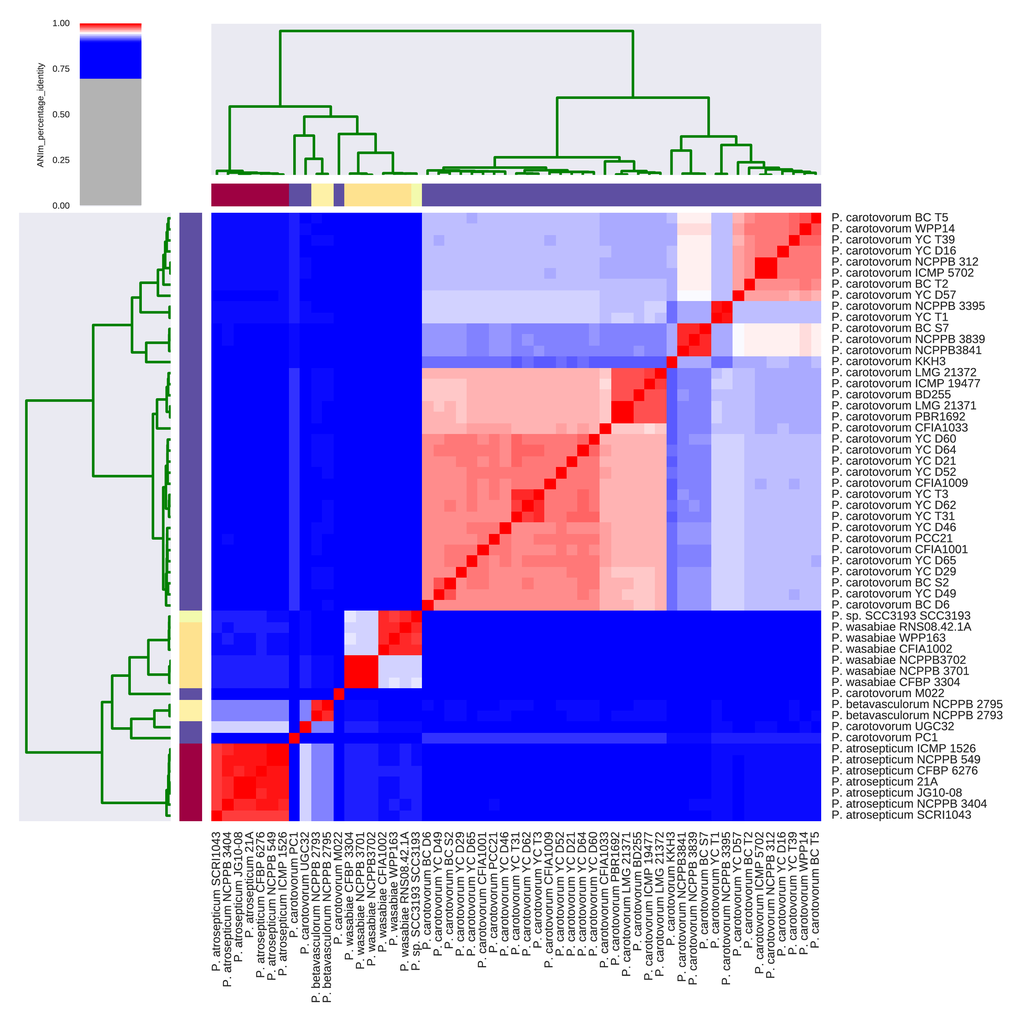

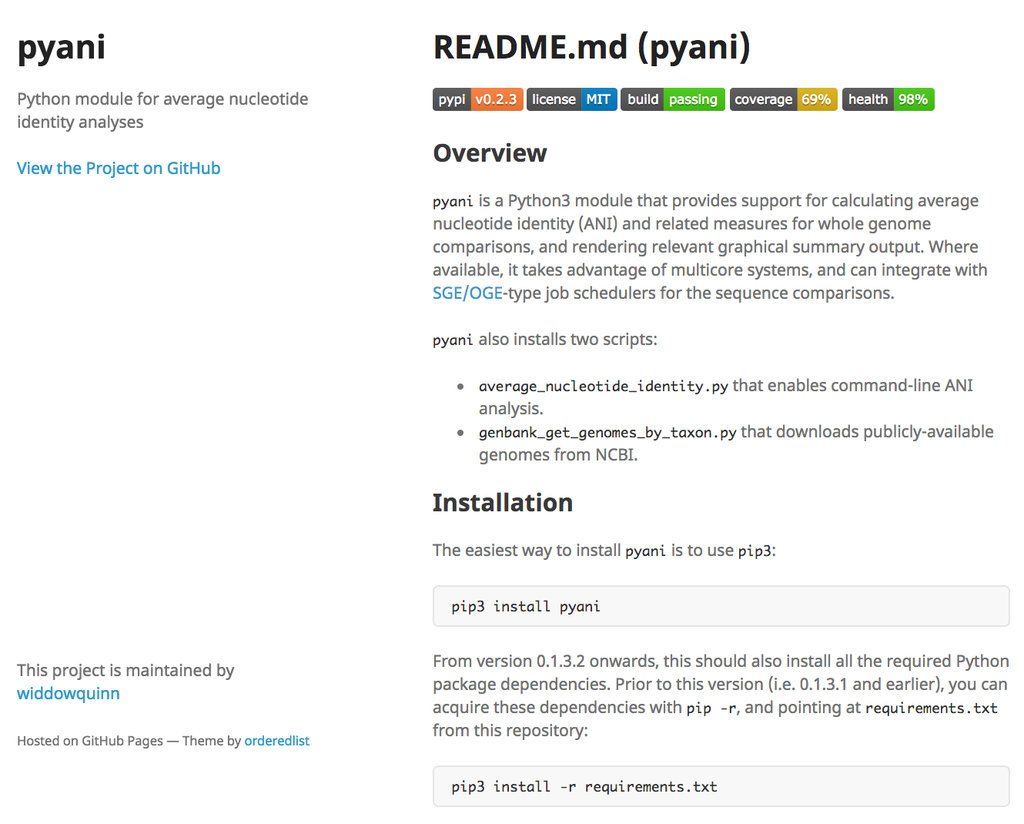

- [Pritchard *et al.* (2015) *Anal. Methods* doi:10.1039/C5AY02550H](https://dx.doi.org/10.1039/C5AY02550H) - `pyani` used on SRE

## `pyani` in the wild

**Downloads**

- Since 2015: 22117
- 2017: 12808
- September 2017: 2164
- Used at `LINBase`: [Life Identification Numbers](http://128.173.74.68/CodeIgniter/index.php/login), Virginia Tech.

## Reclassification: *Pectobacterium*

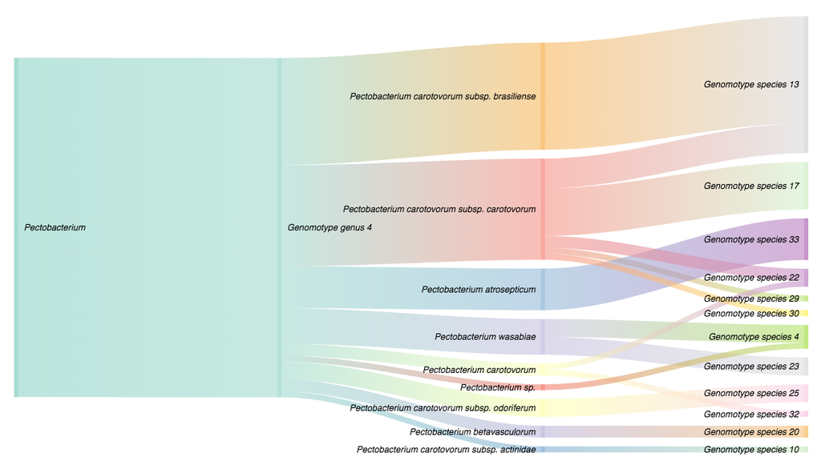

- [Faure *et al.* (2016) *Int. J. Syst. Microbiol* doi:10.1099/ijsem.0.001524](https://dx.doi.org/10.1099/ijsem.0.001524) - Reclassification of *P. wasabiae*

## 3. *Pba* in Scotland

## JHI Collections

**JHI holds historical pathogen samples from 1950s onwards**

- sequence historical samples
- sequence current/recent outbreak samples
- environmental variation
- historical changes (evolution, introduction events)
- **recently won grant to sequence ≈100 historical *Pba* isolates**

**Sequenced ≈50 *P. atrosepticum* isolates from infections (2009-2015)**

- sourced from SASA (Greig, Gerry)
- Illumina sequencing
- `prokka`, `roary`, `QUAST`, `parSNP`

## A note on information

[figure not shown]

Torsten Seeman: https://twitter.com/torstenseemann/status/922735299398008832

## SNP distribution

**SNPs widespread across all *P. atrosepticum* genomes**

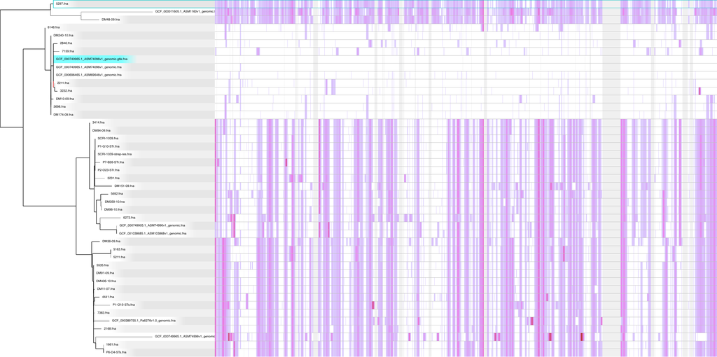

## `parSNP` Clades

*P. atrosepticum* divisible into four clades

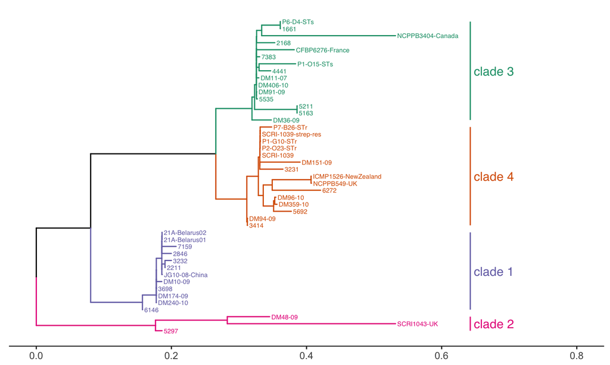

Clades contain isolates found outwith UK/EU (from GenBank)

## Distribution

all four clades widespread, no obvious geographical pattern

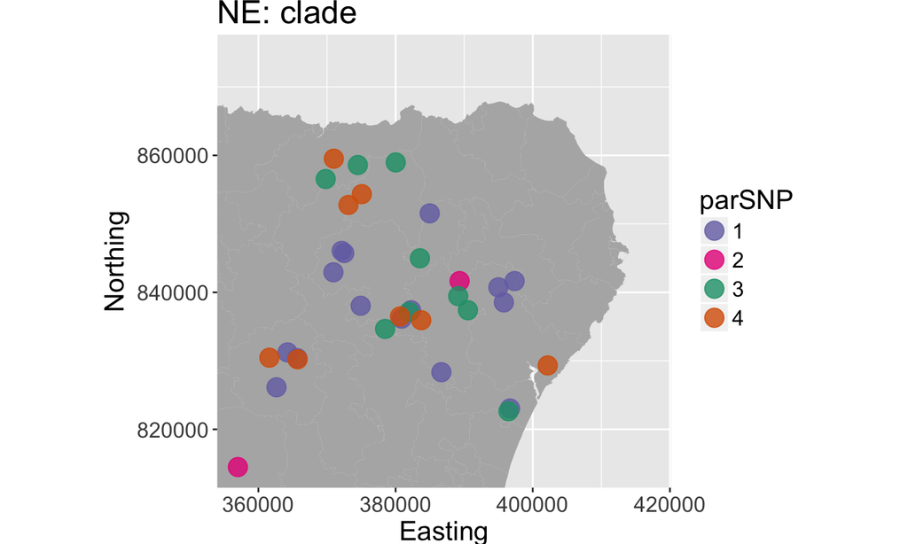

Not variety-related. Coexistence? Separate introductions?

## Pangenomes

| type | range | count |
| --- | --- | --- |
| core | [99,100] | 3191 |
| soft core | [95,99) | 695 |
| shell | [15,95) | 850 |
| cloud | [0,15) | 3766 |

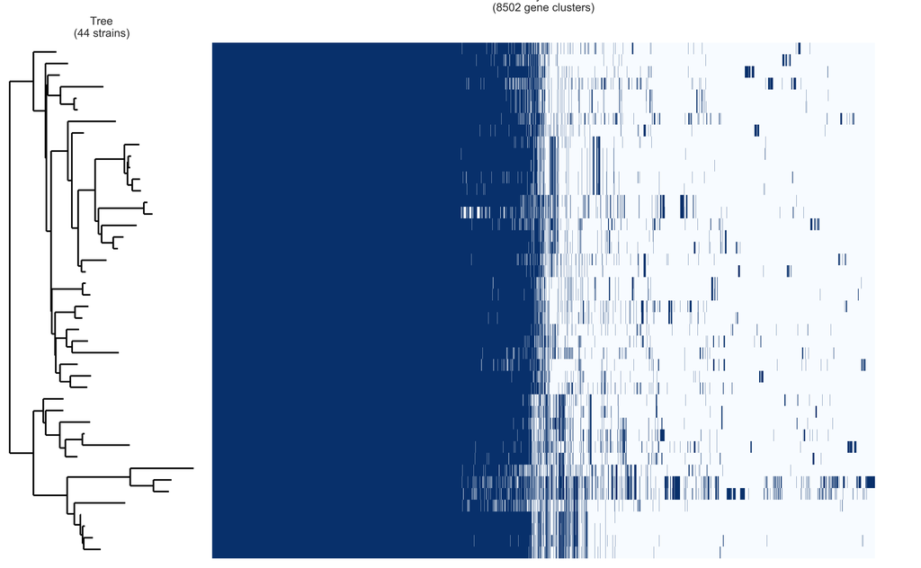

Variation within and between *Pba* clades.

## Accessory genes presence/absence

**accessory gene tree not congruent with the SNP tree**

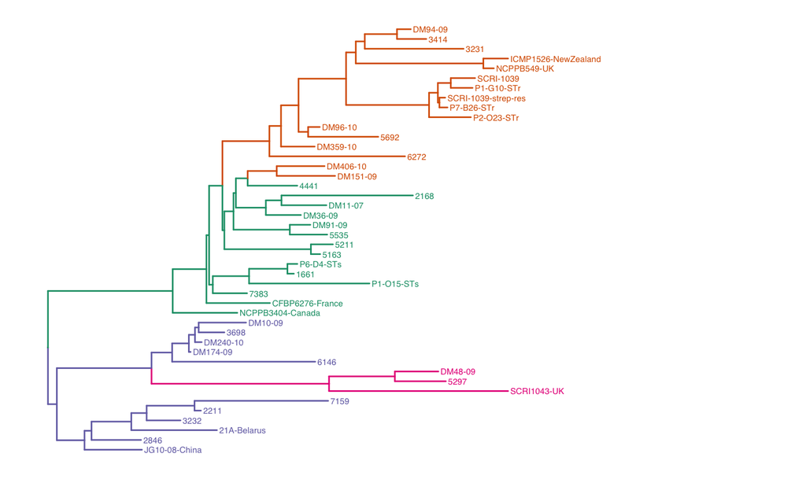

Potential HGT between clades 1 & 2, and clades 3 & 4?

## Further Work

- Sequence 100 historical Scottish/global *Pba* isolates for context
- Core genome/wgMLST phylogeny
- Detailed analysis of genome composition differences
- HGT detection
- Can we identify introductions?

**Acknowledgements**

- Gerry Saddler
- Greig Cahill
- Scottish Society for Crop Research